# Part II - (Prosper Loan Data Exploration)

## by Zao Richardson Ansah

## Investigation Overview

My goal for this project is to explore a dataset containing loan information of approximately 113,937 loans. The dataset is the Prosper loan Dataset, provided by Udacity. I will center this presentation on the process of delving into the various interesting elements in order to establish the connection between the borrowers and the loans they obtained.

I'll start by introducing the relevant features, then discuss how they relate to one another, and last discuss how the influence of a different variable on this association. the features are Borrowers' employment status, their income range, stated monthly income and the loan original amount.

## Dataset Overview

The dataset being used for this project is the Prosper loan Dataset, provided by Udacity. There are 113,937 loans in the dataset with 81 features.

For the analysis, a sub dataset was created having only 20 features of interest and the dataset features two main categories:

- Borrower information
- Loan performance information

## What is the distribution of the borrower's demography accross top 10 states?

The distribution of the borrower's demography accross top 10 states reveals that California (CA) is the state with the highest number of borrowers

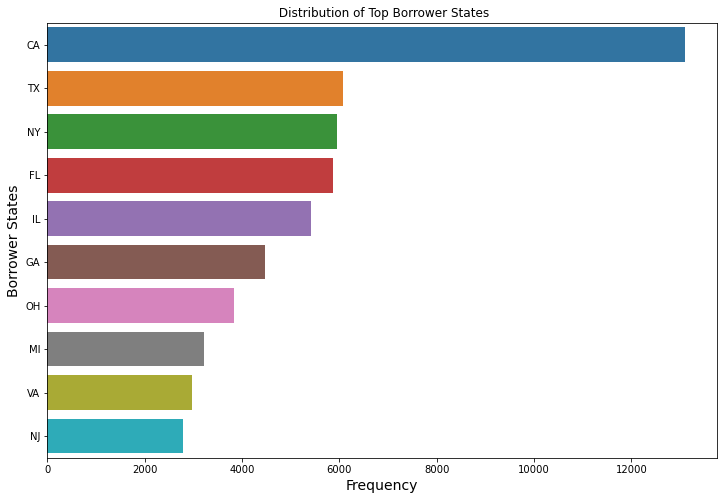

## What is the employment status of Borrowers at the time of listing?

It can be seen from the chart that about 60000+ borrowers were employed at the time posting thier listings

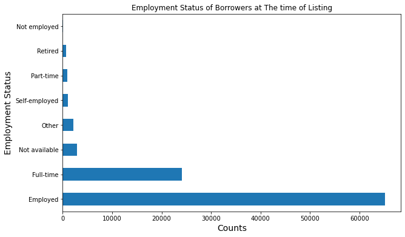

## What was the stated motnhly income of the borrowers ?

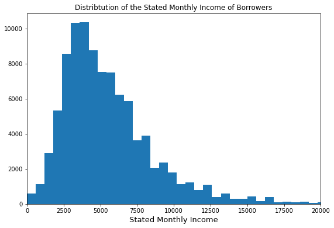

## What is the correlation between 'loan_original_amount', 'stated_monthly_income' and 'borrower_rate'?

Slightly positive correlation between stated_monthly_income and loan_original_amount, where as a negative correlation between stated_monthly income and borrower_rate and loan_original_amount and borrower_rate

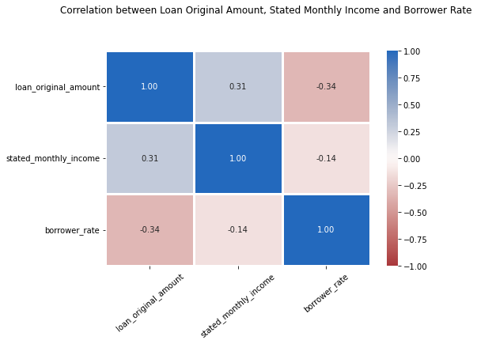

## What is the relationship between Employment status and the numerical variables: 'loan_original_amount', 'stated_monthly_income', 'borrower_rate'?

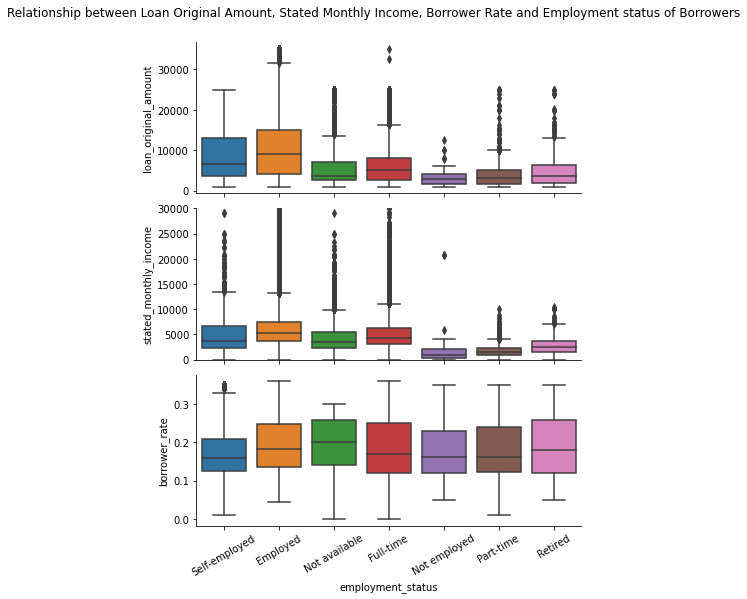

## What is relationship between borrowers loan original amount and their verifiable income status?

Looking at relationship between borrowers loan original amount and their verifiable income status, from the chart, Borrowers with verified income tend to have a higher average loan amount than borrowers without verified income.

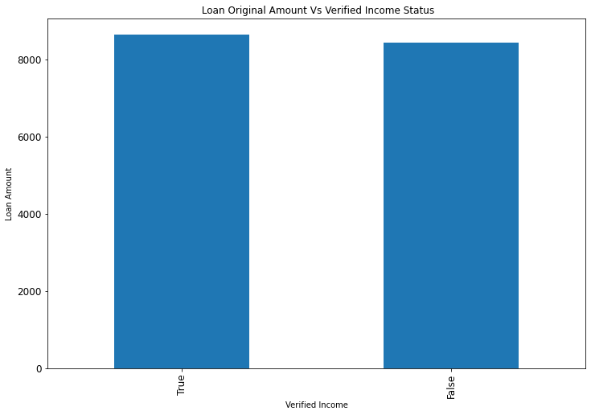

## Does a verified income have effect on the relationship between loan_original_amount and income_range ?

From the chart, it shows that people who earn ($)100,000+ and have verified their income tend to get larger loan original amount than those whose income are not verifiable. The borrowers within most income ranges that have verified incomes tend to get higher loan amounts.

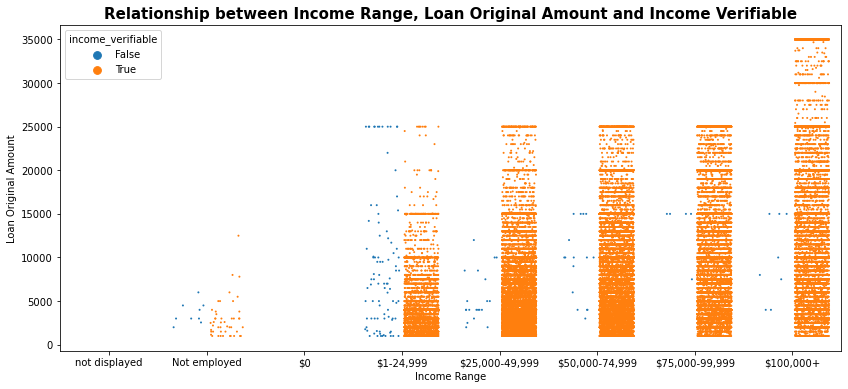